# Solving ordinary differential equations numerically

Cours ENPC — Pratique du calcul scientifique

# Introduction

## Objective

**Goal of this chapter**

Study numerical methods to solve initial value problems:
$$\left \{
\begin{aligned}
& \mathbf{\boldsymbol{x}}'(t) = \mathbf{\boldsymbol{f}}\bigl(t, \mathbf{\boldsymbol{x}}(t)\bigr), \\
& \mathbf{\boldsymbol{x}}(t_0) = \mathbf{\boldsymbol{x}}_0.
\end{aligned}
\right.
\qquad(1)$$
where $\mathbf{\boldsymbol{f}}\colon \mathbf R\times \mathbf R^n \to \mathbf R^n$.

**Application examples**

- Lagrangian mechanics;
- Celestial mechanics;
- Electric circuits;
- Time-dependent partial differential equations:
  $$\left \{
  \begin{aligned}
  \partial_t u &= \partial_x^2 u \\
  u(0, x) &= u_0(x).
  \end{aligned}
  \right.
  \xrightarrow{\text{discretization}}
  \left \{
  \begin{aligned}
  \mathbf{\boldsymbol{x}}' &= \mathsf A \mathbf{\boldsymbol{x}}. \\
  \mathbf{\boldsymbol{x}}(0) &= \mathbf{\boldsymbol{x}}_0.
  \end{aligned}
  \right.$$
  ${\color{green} \rightarrow}$ ubiquitous in science.

**Remark: higher-order differential equations**

Initial value problems of higher order can be recast in form Equation 1.

**Example**: charged particle (wih mass and charge 1) in electric field:
$$\mathbf{\boldsymbol{x}}''(t) = \mathbf{\boldsymbol{E}}\bigl(\mathbf{\boldsymbol{x}}(t)\bigr).$$
Introducing $\mathbf{\boldsymbol{v}} = \mathbf{\boldsymbol{x}}'$, we rewrite this equation as
$$\left \{
\begin{aligned}
& \mathbf{\boldsymbol{v}}'(t) = \mathbf{\boldsymbol{E}}\bigl(\mathbf{\boldsymbol{x}}(t)\bigr), \\
& \mathbf{\boldsymbol{x}}'(t) = \mathbf{\boldsymbol{v}}(t).
\end{aligned}
\right.$$

**Remark: a useful particular case**

When $\mathbf{\boldsymbol{f}}(t, \mathbf{\boldsymbol{x}}) = \mathbf{\boldsymbol{f}}(t)$, the solution is an integral:
$$\mathbf{\boldsymbol{x}}(t) = \mathbf{\boldsymbol{x}}_0 + \int_{t_0}^{t} \mathbf{\boldsymbol{f}}(t) \, \mathrm dt.$$
${\color{green} \rightarrow}$ useful to guess order of convergence of numerical methods

## Analysis of the continuous problem

**Definition: local, maximal, global solution**

A function $\mathbf{\boldsymbol{x}} \colon I \to \mathbf R^n$ is a local solution if $t_0 \in I$ and
$$\left \{
\begin{aligned}
& \mathbf{\boldsymbol{x}}'(t) = \mathbf{\boldsymbol{f}}\bigl(t, \mathbf{\boldsymbol{x}}(t)\bigr) \qquad \forall t \in I \\
& \mathbf{\boldsymbol{x}}(t_0) = \mathbf{\boldsymbol{x}}_0.
\end{aligned}
\right.$$
A local solution $\mathbf{\boldsymbol{x}} \colon I \to \mathbf R^n$ is maximal if it has no extension to a larger interval, and global if $I = \mathbf R$.

**Example**

Consider the equation
$$\left \{
\begin{aligned}
& x'(t) = x(t)^2, \\
& x(0) = 1.
\end{aligned}
\right.$$
The solution $x_* \colon (-\infty, 1) \to \mathbf R$ given by
$$\mathbf{\boldsymbol{x}}_*(t) = \frac{1}{1-t}.$$
is maximal but not global.

**Theorem: existence and uniqueness**

Suppose that

- The function $\mathbf{\boldsymbol{f}}$ is continuous;
- For any bounded set $D \subset \mathbf R\times \mathbf R^n$ containing $(t_0, \mathbf{\boldsymbol{x}}_0)$, there is $L(D)$ such that
  $$\forall \bigl((t, \mathbf{\boldsymbol{x}}_1), (t, \mathbf{\boldsymbol{x}}_2)\bigr) \in D \times D, \qquad
  {\lVert { \mathbf{\boldsymbol{f}}(t, \mathbf{\boldsymbol{x}}_1) - \mathbf{\boldsymbol{f}}(t, \mathbf{\boldsymbol{x}}_2) } \rVert} \leqslant L {\lVert {\mathbf{\boldsymbol{x}}_1 - \mathbf{\boldsymbol{x}}_2} \rVert}.$$

Then

- There exists a unique maximal solution $\mathbf{\boldsymbol{x}}_* \colon (T_-, T_+) \to \mathbf R^n$;
- **Blow-up**: If $T_+$ is finite, then $\lim_{t \to T_+} {\lVert {\mathbf{\boldsymbol{x}}(t)} \rVert} = \infty$, and similarly for $T_-$.

$~$

From now on, $t_0 = 0$ for simplicity.

## Toy problem

**Toy problem**

For numerical illustration, we consider the equation
$$\left\{
\begin{aligned}
x'(t) &= \alpha \bigl(x(t) - \sin(t) \bigr) + \cos(t) \\
x(0) &= x_0.
\end{aligned}
\right.$$

- The exact solution is given by

  $$x(t) = \sin(t) + e^{\alpha t} x_0.$$
- Solutions converge if $\alpha < 0$, and diverge if $\alpha > 0$.

[figure not shown]

## Toy problem

**Toy problem**

For numerical illustration, we consider the equation
$$\left\{
\begin{aligned}
x'(t) &= \alpha \bigl(x(t) - \sin(t) \bigr) + \cos(t) \\
x(0) &= x_0.
\end{aligned}
\right.$$

- The exact solution is given by

  $$x(t) = \sin(t) + e^{\alpha t} x_0.$$
- Solutions converge if $\alpha < 0$, and diverge if $\alpha > 0$.

[figure not shown]

## Toy problem

**Toy problem**

For numerical illustration, we consider the equation
$$\left\{
\begin{aligned}
x'(t) &= \alpha \bigl(x(t) - \sin(t) \bigr) + \cos(t) \\
x(0) &= x_0.
\end{aligned}
\right.$$

- The exact solution is given by

  $$x(t) = \sin(t) + e^{\alpha t} x_0.$$
- Solutions converge if $\alpha < 0$, and diverge if $\alpha > 0$.

[figure not shown]

# The forward and backward Euler methods

## The forward Euler method

**The method**

The forward Euler method is the iteration
$$\mathbf{\boldsymbol{x}}_{n+1} = \mathbf{\boldsymbol{x}}_{n} + \Delta \mathbf{\boldsymbol{f}}(t_n, \mathbf{\boldsymbol{x}}_n),$$
with $\Delta$ the time step.

**Remark: link with numerical quadrature**

When $\mathbf{\boldsymbol{f}}(t, \mathbf{\boldsymbol{x}}) = \mathbf{\boldsymbol{f}}(t)$, the method performs the approximation
$$\int_0^{n \Delta} \mathbf{\boldsymbol{f}}(t) \, \mathrm dt \approx \sum_{i=0}^{n-1} \Delta \mathbf{\boldsymbol{f}}(i \Delta).$$
${\color{green} \rightarrow}$ This is the left endpoint rule for numerical integration.

${\color{green} \rightarrow}$ The error scales as $\mathcal O(\Delta)$ in this case.

**Question**: is this true in general?

[figure not shown]

## The forward Euler method: geometric interpretation

**Example problem**

We consider the toy problem from the beginning:
$$\left\{
\begin{aligned}
x'(t) &= \alpha \bigl(x(t) - \sin(t) \bigr) + \cos(t) \\
x(0) &= 0,
\end{aligned}
\right.$$
with $\alpha = 0.15$.

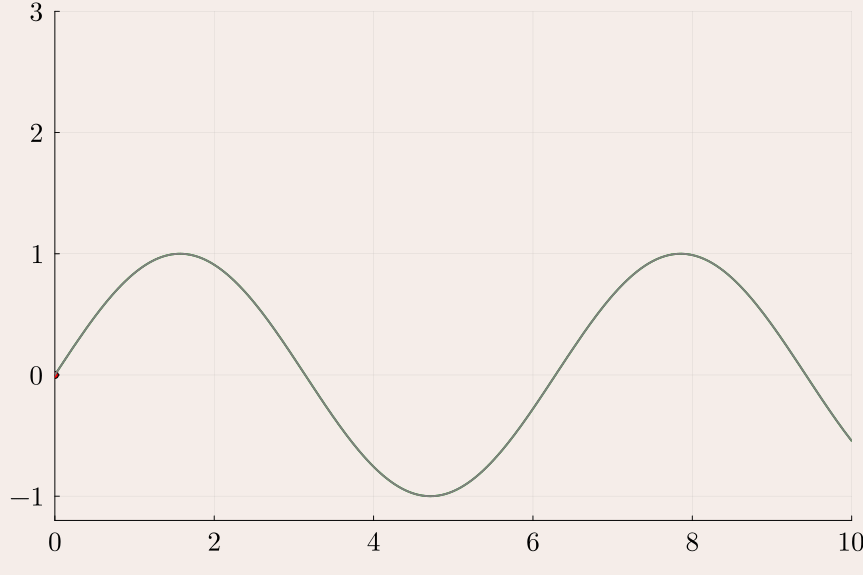

## The forward Euler method: illustration of the convergence

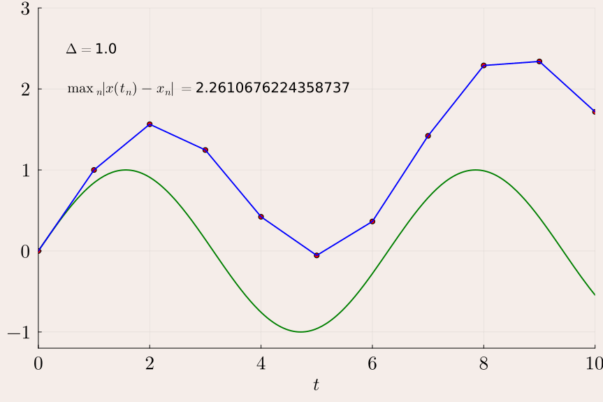

## Estimating the rate of convergence numerically

**Estimation of the order of convergence**

**Question:** how to estimate the order $p$?
$$\max_n |x(t_n) - x_n| = \mathcal O(\Delta^{\color{blue} p})$$

**Answer**: assume that
$$u(Δ) = C \Delta^{\color{blue} p}.$$
Then
$$\log\bigl(u(\Delta)\bigr)
= \log C + {\color{blue} p} \log(\Delta)$$
In other words, $\log(u)$ is an affine function of $\log(\Delta)$!

${\color{green} \rightarrow}$ Enables calculating $p$ using linear fit.

[figure not shown]

```julia
using Polynomials
fit(log.(Δs), log.(errors), 1)
```

0.8839261276181305 + 0.9832294185740849∙x

## The forward Euler method: error analysis

**Convergence theorem**

Assume that

- there exists a unique solution $\mathbf{\boldsymbol{x}}(t) \colon [0, T] \to \mathbf R^n$, in $C^2$ with
  $$M := \sup_{t \in [0,T]} {\lVert {\mathbf{\boldsymbol{x}}''(t)} \rVert}.$$
- the function $\mathbf{\boldsymbol{f}}(t, \mathbf{\boldsymbol{x}})$ is globally Lipschitz in $\mathbf{\boldsymbol{x}}$ with constant $L$.

Then the following error estimate holds:
$$\begin{equation}
\forall n,
\quad
{\lVert {\mathbf{\boldsymbol{x}}(t_n) - \mathbf{\boldsymbol{x}}_n} \rVert}
\leqslant
\frac{{\color{blue} \Delta} M}{2} \left( \frac{\mathop{\mathrm{e}}^{L t_n} - 1}{L} \right),
\end{equation}$$

**Proof (dimension 1 for simplicity)**

- Let $e_n = x(t_n) - x_n$. By Taylor, there is $\tau_n \in [t_n, t_{n+1}]$ such that
  $$e_n = e_{n-1} + \Delta \Bigl( f\bigl(t_{n-1}, x(t_{n-1})\bigr) - f\bigl(t_{n-1}, x_{n-1}\bigr) \Bigr) + \frac{\Delta^2}{2} x''(\tau_n).$$
- By Lipschitz continuity,
  $${\lvert {e_{n}} \rvert} \leqslant(1 + \Delta L) {\lvert {e_{n-1}} \rvert} + \frac{M \Delta^2}{2}.$$
- Iterating this inequality, we deduce
  $$\begin{aligned}
  |e_{n}|
  &\leqslant(1 + \Delta L) \Bigl( (1 + \Delta L) {\lvert {e_{n-2}} \rvert} + \frac{M \Delta^2}{2} \Bigr) + \frac{M \Delta^2}{2}\\
  &\leqslant\dotsc
  \leqslant(1 + \Delta L)^{n} {\lvert {e_{0}} \rvert} + \sum_{i=1}^{n} (1 + \Delta L)^{n-i} \frac{M \Delta^2}{2}.
  \end{aligned}$$
- Using the formula for geometric series, we have
  $${\lvert {e_{n}} \rvert}
  \leqslant(1 + \Delta L)^{n} {\lvert {e_{0}} \rvert} + \frac{(1+\Delta L)^{n} - 1}{\Delta L} \left( \frac{\Delta^2 M}{2} \right).$$

## The forward Euler method: numerical instability

**Definition: numerical instability**

A method is numerically unstable when the numerical solution diverges but the exact solution does not.

**Example problem**

Consider the toy problem from the beginning
$$\left\{
\begin{aligned}
x'(t) &= f(t, x) := \alpha \bigl(x(t) - \sin(t) \bigr) + \cos(t) \\
x(0) &= x_0.
\end{aligned}
\right.$$

- For $\alpha < 0$, exact solutions converge with time scale $|\alpha|^{-1}$.
- For $\alpha \ll -1$, presence of two widely separated time scales.

  ${\color{green} \rightarrow}$ short scale $|\alpha|^{-1}$, and long scale $2\pi$ (period of $\sin$)

  ${\color{green} \rightarrow}$ the equation is called stiff.
- We observe numerical instability if $|1 + \Delta \alpha| > 1$. Why?

  ${\color{green} \rightarrow}$ in general, numerical stability depends on shortest scale.

$\alpha = -10$, $\Delta = .18$

$~$

[figure not shown]

## The forward Euler method: numerical instability

**Definition: numerical instability**

A method is numerically unstable when the numerical solution diverges but the exact solution does not.

**Example problem**

Consider the toy problem from the beginning
$$\left\{
\begin{aligned}
x'(t) &= f(t, x) := \alpha \bigl(x(t) - \sin(t) \bigr) + \cos(t) \\
x(0) &= x_0.
\end{aligned}
\right.$$

- For $\alpha < 0$, exact solutions converge with time scale $|\alpha|^{-1}$.
- For $\alpha \ll -1$, presence of two widely separated time scales.

  ${\color{green} \rightarrow}$ short scale $|\alpha|^{-1}$, and long scale $2\pi$ (period of $\sin$)

  ${\color{green} \rightarrow}$ the equation is called stiff.
- We observe numerical instability if $|1 + \Delta \alpha| > 1$. Why?

  ${\color{green} \rightarrow}$ in general, numerical stability depends on shortest scale.

$\alpha = -10$, $\Delta = .22$

$~$

[figure not shown]

## Absolute stability

**Definition: absolute stability**

Consider the model equation
$$\left\{
\begin{aligned}
x'(t) &= \lambda x(t), \\
x(0) &= 1.
\end{aligned}
\right.$$
A numerical scheme is called absolutely stable if
$$\lvert x_n \rvert \xrightarrow[n \to \infty]{} 0.$$
The absolute stability region is by definition
$$\mathcal A := \{ z \in \mathbf C: \text{${\lvert {x_n} \rvert} \to 0$ when $\Delta \lambda = z$} \} \subset \mathbf C.$$

**Absolute stability of the forward Euler method**

The forward Euler iteration for the model equation reads
$$x_{n+1} = x_n + \Delta \lambda x_n = (1 + \Delta \lambda) x_n.$$
The scheme is absolutely stable iff $|1 + \Delta \lambda| < 1$.

```julia
xlims, ylims = (-5, 1), (-2, 2)
x = LinRange(xlims..., 200)
y = LinRange(ylims..., 200)
stable = @. clamp(abs(1 + x' + im*y), 0, 2)
Plots.contourf(x, y, stable, c=cgrad(:Pastel1_3, rev=true),
               aspect_ratio=:equal, levels=[0., 1., 2.],
               xlabel=L"\Re(\Delta \lambda)",
               ylabel=L"\Im(\Delta \lambda)",
               xlims=xlims, ylims=ylims, bg=:transparent)
Plots.contour!(x, y, stable, color=:red,
               levels=[0., 1., 2.], colorbar=:none)
Plots.vline!([0], color=:gray)
Plots.hline!([0], color=:gray)
```

[figure not shown]

## Absolute stability: illustration for model equation

**Example problem**

Consider the equation
$$\left\{
\begin{aligned}
x'(t) &= - x(t), \\
x(0) &= 1.
\end{aligned}
\right.$$
Absolute stability of forward Euler if $\Delta < 2$.

$\Delta = \frac{1}{2}$

$~$

[figure not shown]

## Absolute stability: illustration for model equation

**Example problem**

Consider the equation
$$\left\{
\begin{aligned}
x'(t) &= - x(t), \\
x(0) &= 1.
\end{aligned}
\right.$$
Absolute stability of forward Euler if $\Delta < 2$.

$\Delta = 2$

$~$

[figure not shown]

## Absolute stability: illustration for model equation

**Example problem**

Consider the equation
$$\left\{
\begin{aligned}
x'(t) &= - x(t), \\
x(0) &= 1.
\end{aligned}
\right.$$
Absolute stability of forward Euler if $\Delta < 2$.

$\Delta = 2.5$

$~$

[figure not shown]

## The main application of absolute stability: PDEs

**Example: heat equation**

Space discretization of the heat equation
$$\left \{
\begin{aligned}
&\partial_t u = \partial_x^2 u, \\
&u(t, 0) = u(t, 1) = 0,
\end{aligned}
\right.$$
by the finite difference method leads to the differential equation
$$\mathbf{\boldsymbol{u}}' := \mathsf A \mathbf{\boldsymbol{u}},
\qquad
\mathsf A :=
\frac{1}{h^2}
\begin{pmatrix}
-2 & 1 \\
1 & -2 & 1 \\
& 1 & -2 & 1 \\
& & \ddots & \ddots & \ddots & \\
& & & 1 & -2 & 1 \\
& & & & 1 & -2 \\
\end{pmatrix},$$
where $h$ is the spatial step. The **forward Euler method** for this system reads
$$\mathbf{\boldsymbol{u}}_{n+1}
= \mathbf{\boldsymbol{u}}_{n} + \Delta \mathsf A \mathbf{\boldsymbol{u}}_{n}
= (\mathsf I + \Delta \mathsf A) \mathbf{\boldsymbol{u}}_{n}.$$
${\color{green} \rightarrow}$ numerical stability if $\Delta \lambda \in \mathcal A$, i.e. $|1 + \Delta \lambda|< 1$, for any eigenvalue $\lambda$ of $\mathsf A$.

${\color{green} \rightarrow}$ since $\max_i |\lambda_i| \propto \frac{1}{h^2}$, stability requires $\Delta = \mathcal O(h^2)$…

## The backward Euler method

**The method**

The backward Euler method is the iteration
$$\mathbf{\boldsymbol{x}}_{n+1} = \mathbf{\boldsymbol{x}}_{n} + \Delta \mathbf{\boldsymbol{f}}({\color{red}t_{n+1}}, {\color{red}\mathbf{\boldsymbol{x}}_{n+1}}),$$
with $\Delta$ the time step.

${\color{green} \rightarrow}$ Nonlinear equation to solve at each step!

**Remark: link with numerical quadrature**

When $\mathbf{\boldsymbol{f}}(t, \mathbf{\boldsymbol{x}}) = \mathbf{\boldsymbol{f}}(t)$, the method performs the approximation
$$\int_0^{n \Delta} \mathbf{\boldsymbol{f}}(t) \, \mathrm dt \approx \sum_{i=1}^{n} \Delta \mathbf{\boldsymbol{f}}(i \Delta).$$
${\color{green} \rightarrow}$ This is the right endpoint rule for numerical integration.

${\color{green} \rightarrow}$ The error scales as $\mathcal O(\Delta)$ in this case.

**Proposition absolute stability**

The stability region of the backward Euler method is
$$\mathcal A = \left\{ z \in \mathbf C: \frac{1}{|1 - \Delta \lambda|} < 1 \right\}$$

[figure not shown]

${\color{green} \rightarrow}$ Stable for all $\Re(\Delta \lambda) < 0$, “unconditional stability”

## Absolute stability: illustration for model equation

**Example problem**

Consider the equation
$$\left\{
\begin{aligned}
x'(t) &= - x(t), \\
x(0) &= 1.
\end{aligned}
\right.$$
Absolute stability for all $\Delta > 0$!

$\Delta = 2.5$

$~$

[figure not shown]

# Higher-order one-step methods

## Explicit Taylor methods

**Motivating idea**

By differentiating the equation
$$\mathbf{\boldsymbol{x}}'(t) = \mathbf{\boldsymbol{f}}\bigl(t, \mathbf{\boldsymbol{x}}(t)\bigr),$$
we have access to higher-order derivatives of $\mathbf{\boldsymbol{x}}$, e.g.
$$\begin{aligned}
\mathbf{\boldsymbol{x}}'' &= \mathbf{\boldsymbol{f}}_2\bigl(t, \mathbf{\boldsymbol{x}}(t)\bigr),
\qquad \mathbf{\boldsymbol{f}}_2(t, \mathbf{\boldsymbol{x}}) := (\partial_t + \mathbf{\boldsymbol{f}}(t, \mathbf{\boldsymbol{x}}) \cdot \nabla_{\mathbf{\boldsymbol{x}}}) \mathbf{\boldsymbol{f}}(t, \mathbf{\boldsymbol{x}}) \\
\mathbf{\boldsymbol{x}}''' &= \mathbf{\boldsymbol{f}}_3\bigl(t, \mathbf{\boldsymbol{x}}(t)\bigr),
\qquad \mathbf{\boldsymbol{f}}_3(t, \mathbf{\boldsymbol{x}}) := (\partial_t + \mathbf{\boldsymbol{f}}(t, \mathbf{\boldsymbol{x}}) \cdot \nabla_{\mathbf{\boldsymbol{x}}}) \mathbf{\boldsymbol{f}}_2(t, \mathbf{\boldsymbol{x}}), \\
&\dots
\end{aligned}$$
This motivates the so-called Taylor methods:
$$\mathbf{\boldsymbol{x}}_{n+1} = \mathbf{\boldsymbol{x}}_n + \Delta \mathbf{\boldsymbol{f}}(t_n, \mathbf{\boldsymbol{x}}_n) + \frac{\Delta^2}{2} \mathbf{\boldsymbol{f}}_2(t_n, \mathbf{\boldsymbol{x}}_n) + \dotsc + \frac{\Delta^p}{p!} \mathbf{\boldsymbol{f}}_p(t_n, \mathbf{\boldsymbol{x}}_n).$$

**Remarks**

- Note that for $p = 1$, this is the forward Euler method;
- The error scales as $\mathcal O(\Delta^p)$ under appropriate assumptions.
- By construction, exact when $\mathbf{\boldsymbol{x}}(t)$ is polynomial of degree $p$.

**Proposition: absolute stability**

The absolute stability region of the Taylor method is
$$\mathcal A = \left\{ z \in \mathbf C: \left|1 + z + \dotsc + \frac{z^p}{p!} \right| < 1 \right\}$$

[figure not shown]

## Runge-Kutta methods

**Definition: explicit Runge-Kutta method**

An explicit Runge–Kutta method with $p$ stages is of the form
$$\begin{aligned}
\mathbf{\boldsymbol{x}}_{n+1} &= \mathbf{\boldsymbol{x}}_n + \Delta \sum_{i=1}^p b_i \mathbf{\boldsymbol{k}}_i \\
\mathbf{\boldsymbol{k}}_1 &= \mathbf{\boldsymbol{f}}(t_n, \mathbf{\boldsymbol{x}}_n), \\
\mathbf{\boldsymbol{k}}_2 &= \mathbf{\boldsymbol{f}}\bigl(t_n + c_2 \Delta, \mathbf{\boldsymbol{x}}_n+\Delta(a_{21} \mathbf{\boldsymbol{k}}_1)\bigr), \\
\mathbf{\boldsymbol{k}}_3 &= \mathbf{\boldsymbol{f}}\bigl(t_n + c_3 \Delta, \mathbf{\boldsymbol{x}}_n+\Delta(a_{31} \mathbf{\boldsymbol{k}}_1 + a_{32} \mathbf{\boldsymbol{k}}_2)\bigr), \\
&\;\;\vdots \\
\mathbf{\boldsymbol{k}}_p &= \mathbf{\boldsymbol{f}}\left(t_n + c_p \Delta, \mathbf{\boldsymbol{x}}_n + \Delta \sum_{j = 1}^{p-1} a_{pj} \mathbf{\boldsymbol{k}}_j\right),
\end{aligned}$$

${\color{green} \rightarrow}$ Derivatives of $\mathbf{\boldsymbol{f}}$ not necessary!

**Remarks**

- Construction tedious and not discussed here;
- Most widely used in applications;
- Error scales as $\mathcal O(\Delta^p)$ for appropriate coefficients;

**Example: Heun’s method**

Heun’s method is a Runge-Kutta method of order 2 and reads
$$\mathbf{\boldsymbol{x}}_{n+1} = \mathbf{\boldsymbol{x}}_n
+ \frac{\Delta}{2}\mathbf{\boldsymbol{f}}(t_n, \mathbf{\boldsymbol{x}}_n)
+ \frac{\Delta}{2} \mathbf{\boldsymbol{f}} \bigl( t_n + \Delta, \mathbf{\boldsymbol{x}}_n + \Delta \mathbf{\boldsymbol{f}}(t_n, \mathbf{\boldsymbol{x}}_n) \bigr).$$

**Proposition: same stability region as Taylor’s method**

The absolute stability region of a Runge-Kutta method of order $p$ is
$$\mathcal A = \left\{ z \in \mathbf C: \left|1 + z + \dotsc + \frac{z^p}{p!} \right| < 1 \right\}$$

## Further readings

Some of the topics we did not cover include

- Multistep methods;
- Implicit Runge-Kutta methods;
- Adaptive time-stepping;
- Symplectic schemes for Hamiltonian systems;
- …

[figure not shown]